# Clase 1: Quarto

Creado por

Bastián Olea Herrera

Fecha de publicación

1 de abril de 2025

**Aviso**

Este reporte es el que creamos durante la clase. Si buscas la guía con instrucciones para generar un reporte, está en el archivo `clase_1.qmd`!

## Markdown

Esta es la clase de Quarto[^1]. Vamos a ver los principios de markdown:

- **negrita**
- *itálica*
- tachado
- `código`[^2]
- [Sitio web sobre markdown](https://quarto.org/docs/authoring/markdown-basics.html)

`[Sitio web sobre markdown](https://quarto.org/docs/authoring/markdown-basics.html)`

## Temas

https://quarto.org/docs/output-formats/html-themes.html

## Código

El dataset Iris cuenta con 100 observaciones y 5 variables. La variable de especies tiene 2 tipos de plantas distintas: setosa, versicolor.

Para cargar el dataset Iris, ejecutamos `iris`:

```r
iris
```

Insertar un bloque de código (*chunk*):

```r
library(dplyr)
head(iris)
```

```
  Sepal.Length Sepal.Width Petal.Length Petal.Width Species
1          5.1         3.5          1.4         0.2  setosa
2          4.9         3.0          1.4         0.2  setosa
3          4.7         3.2          1.3         0.2  setosa
4          4.6         3.1          1.5         0.2  setosa
5          5.0         3.6          1.4         0.2  setosa
6          5.4         3.9          1.7         0.4  setosa
```

### Gráficos

Este gráfico es morado y muy bonito. Me gusta mucho mucho mucho mucho mucho mucho mucho mucho.

Estos son los resultados de mi tesis:

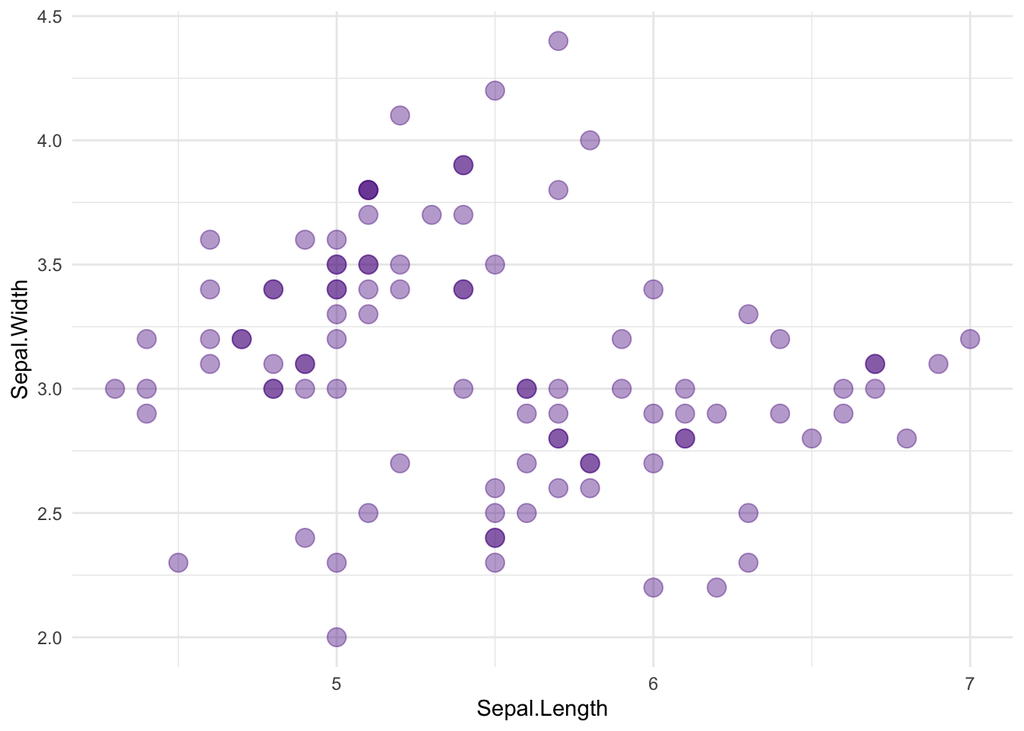

### Columnas

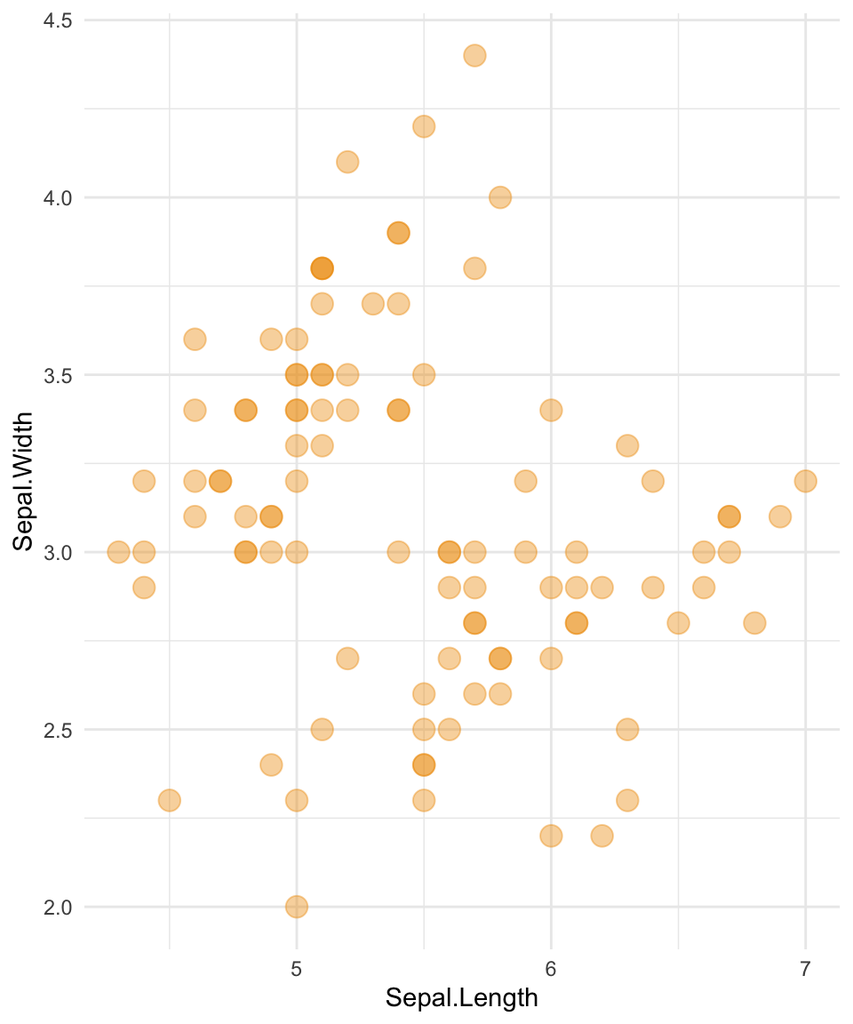

En este gráfico podemos ver que los puntitos son muy anaranjados. Ejemplo, ejemplo, ejemplo, ejemplo, ejemplo, ejemplo, ejemplo, ejemplo, ejemplo, ejemplo, ejemplo, ejemplo, ejemplo, ejemplo, ejemplo, ejemplo, ejemplo.

### Pestañas

```r
library(gt)
iris |>
  head(n = 10)
```

```
   Sepal.Length Sepal.Width Petal.Length Petal.Width Species
1           5.1         3.5          1.4         0.2  setosa
2           4.9         3.0          1.4         0.2  setosa
3           4.7         3.2          1.3         0.2  setosa
4           4.6         3.1          1.5         0.2  setosa
5           5.0         3.6          1.4         0.2  setosa
6           5.4         3.9          1.7         0.4  setosa
7           4.6         3.4          1.4         0.3  setosa
8           5.0         3.4          1.5         0.2  setosa
9           4.4         2.9          1.4         0.2  setosa
10          4.9         3.1          1.5         0.1  setosa
```

**Explicación**

Ahora vamos a ver el dataset, en el gráfico 1 bla bla, en el 2 bla bla…

**Gráfico 1**

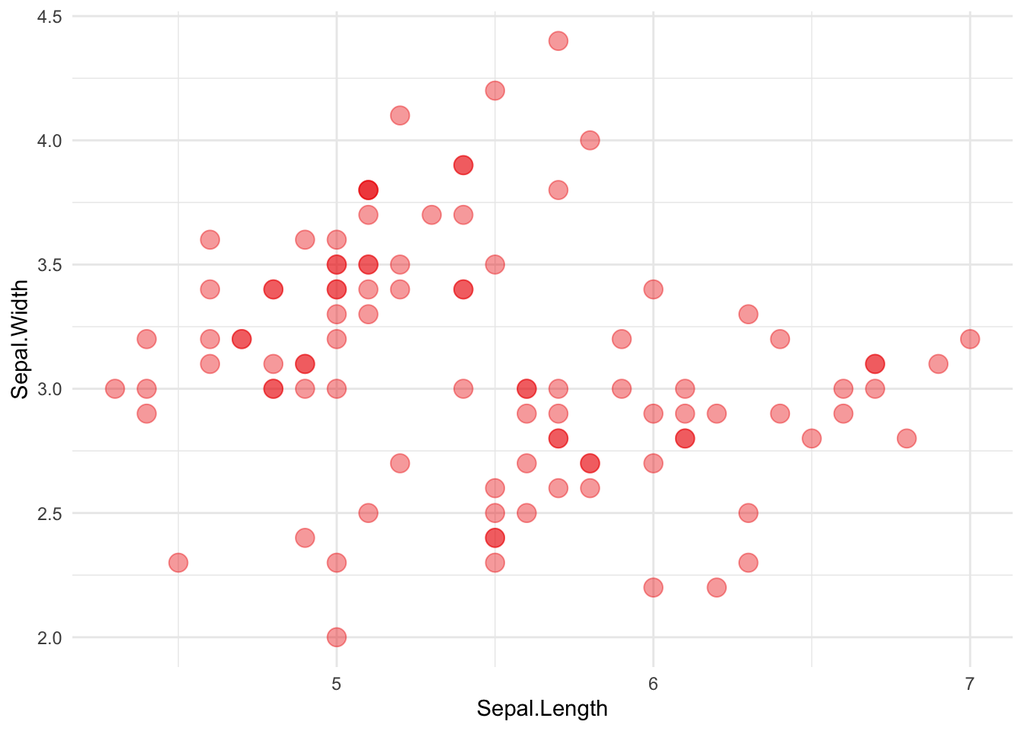

```r
iris |>
  ggplot() +
  aes(x = Sepal.Length, y = Sepal.Width) +
  geom_point(color = "red2", size = 4, alpha = 0.4) +
  theme_minimal()
```

**Gráfico por colores**

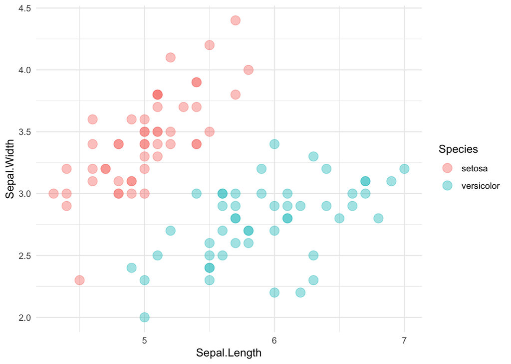

```r
iris |>
  ggplot() +
  aes(x = Sepal.Length, y = Sepal.Width, color = Species) +
  geom_point(size = 4, alpha = 0.4) +
  theme_minimal()
```

**Gráfico boxplot**

Este es un gráfico de cajas

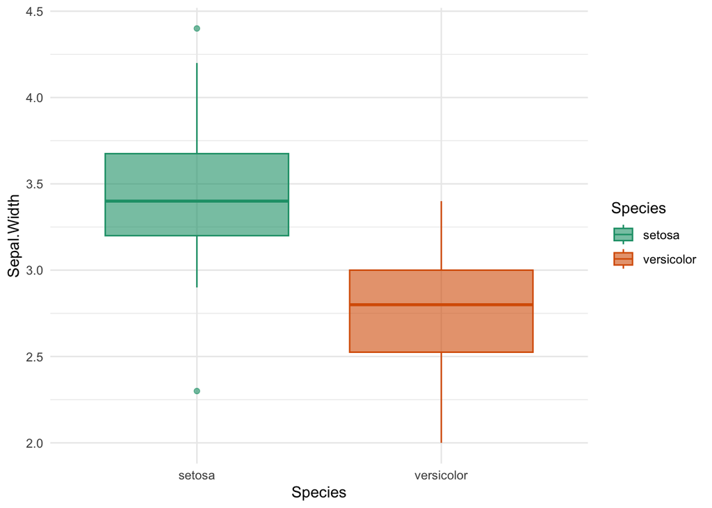

```r
iris |>
  ggplot() +
  aes(x = Species, y = Sepal.Width, color = Species, fill = Species) +
  geom_boxplot(alpha = 0.6) +
  scale_fill_brewer(palette = "Dark2") +
  scale_color_brewer(palette = "Dark2") +
  theme_minimal()
```

Holaaa

## Notas

[^1]: Es la primera de 2 sesiones.
[^2]: lo que quede dentro de las comillas nos e va a interpretar, sino que va a salir directamente como está escrito